# initial_analysis

## Initial Analysis

- Checking for survey completeness
- Descriptive statistics
- Correlations and Alpha

## Initial Analysis

In the survey builder, go to the “Data & Analysis Tab”:

[figure not shown]

## Initial Analysis

- You can start by checking the response quality tab to automatically filter low-quality responses.

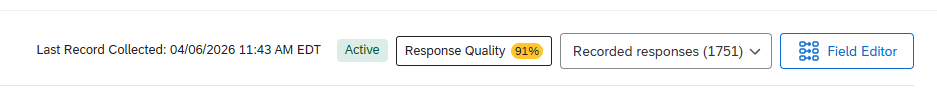

## Initial Analysis

- Once you’re set, you can export the survey.

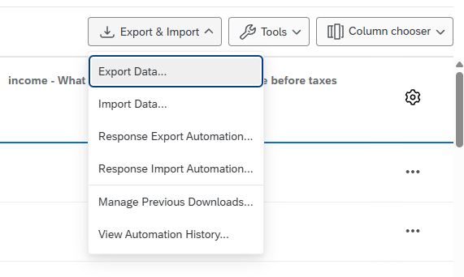

## Initial Analysis

- You *can* export as a `.csv` file, but this may cause you to lose some useful formatting information, so I recommend exporting the data as an SPSS file (this will have a `.sav`) extension.

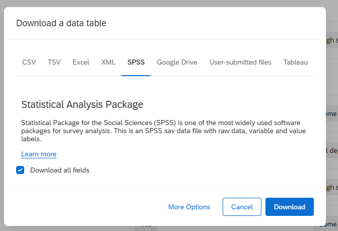

## Data import

- Hit “Import Dataset” in the top-right window and select “From SPSS”
- Hit Browse when the new window opens, then locate your file.

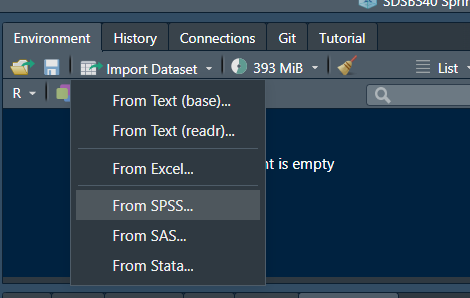

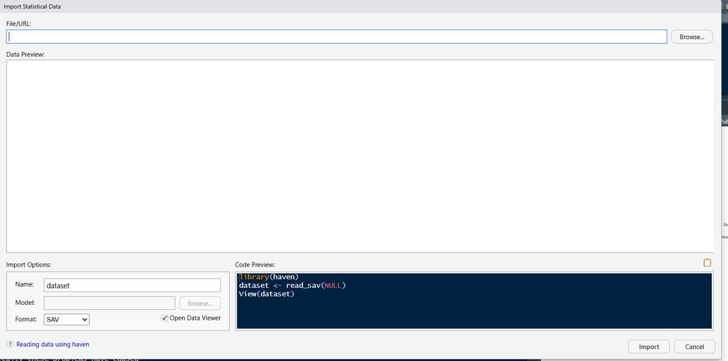

## Data import

## Data import

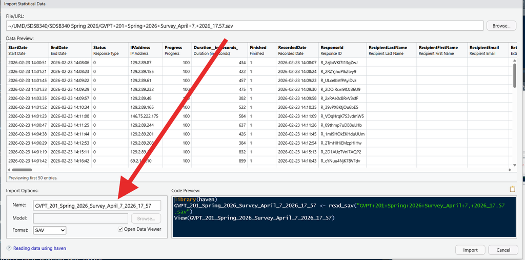

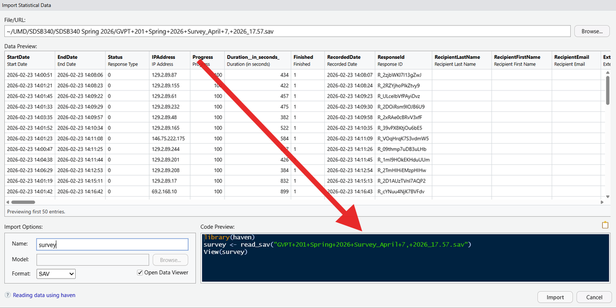

## Data import

When working in SPSS formatted data:

- Column names will come from whatever you named your question in Qualtrics. This may just be “Q1” “Q2” “Q3”
- The column labels will show the full text of your questions.

## Data import

(Since I know many of you don’t have many responses yet, I’ve included some example Qualtrics data that you can import by running the code below.

```r
library(tidyverse)
library(haven)
library(labelled)
library(gt)
library(gtsummary)

survey<-haven::read_sav('https://github.com/Neilblund/SDSB340-Spring-2026/raw/refs/heads/master/Data/raw_survey.sav')|>
  as_factor()
```

## Data import

When working with SPSS formatted data:

- Categorical variables will be in an SPSS format, and you’ll need to convert them to factor variables using `as_factor()`.
- In most cases, you can do this non-selectively to the entire data set:

```r
survey<-survey|>
  as_factor()
```

- Be careful when using this on numeric data.

## What to do

- Cleanup
- Basic Descriptive Statistics
- Exploratory Data Analysis

## Multi-response items

The “race” question on this survey allowed respondents to select more than one option. This makes sense from a questionnaire design perspective, but its hard to work with in an analysis.

```r
survey|>
  select(starts_with("race_")) # selecting columns that start with "race_"
```

| race_1 | race_2 | race_3 | race_4 | race_5 | race_6 | race_7 |
| --- | --- | --- | --- | --- | --- | --- |
| White or Caucasian | NA | NA | NA | NA | NA | NA |
| White or Caucasian | NA | NA | NA | NA | NA | NA |
| NA | Black or African American | NA | NA | NA | NA | NA |
| White or Caucasian | NA | NA | NA | NA | NA | NA |
| NA | NA | NA | Asian | NA | NA | NA |
| White or Caucasian | NA | NA | NA | NA | NA | NA |
| NA | NA | NA | NA | NA | Other | NA |
| NA | NA | NA | Asian | NA | NA | NA |
| White or Caucasian | NA | NA | Asian | NA | NA | NA |
| White or Caucasian | NA | NA | NA | NA | NA | NA |

### Multi-response items

The vast majority of respondents only gave one (or zero) answers to this question. So the easiest approach here might be to classify people by their selected race, and then add a “multi-racial” category for everyone else.

```r
race_counts<-survey|>
  select(starts_with("race_"))|> # selecting columns that start with "race_"
  apply(X=_, 1, FUN=function(x) sum(!is.na(x)))

table(race_counts)
```

```
race_counts
   0    1    2    3    4    5    6    7
 377 1249  107   13    1    1    1    2
```

### Multi-response items

```r
summarize_race<-function(x){
  x<-unname(x[which(!is.na(x))]) # get the non-NA values from x
  if(length(x) == 0){            # If non are selected, then add NA
    x<-NA
  }
  if(length(x)>1){
    x<-"Multiple races" # the default if R picked multiple races
  }

  return(x)
}

rs<-survey|>
  select(starts_with("race_"))|> # selecting columns that start with "race_"
  apply(X=_, 1, FUN=function(x) summarize_race(x))|> # applying the function to each row
  unlist()                                           # converting from a list to a vector

survey$summary_race<-rs # add the variable to the data set
```

### Multi-response items

Using `case_when` allows for more fine grained control over complex conditional statements.

Each argument in `case_when` is evaluated in sequence. `.default` sets the values for any elements that aren’t matched by any of the preceding conditions.

### Multi-response items

We can use a `case_when` statement to get a 6 category measure that combines race and ethnicity:

```r
race_counts<-survey|>
  select(starts_with("race_"))|>
  apply(X=_, 1, FUN=function(x) sum(!is.na(x)))


survey<-survey |>
  mutate(
    ethnicity_race = case_when(
      race_counts == 0 ~ NA,
      ethnicity == "Yes" ~ "Hispanic/Latino",
      race_counts > 1 ~ "Multiple races, non-Hispanic",
      !is.na(race_1) ~  "White, non-Hispanic",
      !is.na(race_2) ~ "Black, non-Hispanic",
      !is.na(race_4) ~ "Asian, non-Hispanic",
      .default = "Other, non-Hispanic"

    )
  )

var_label(survey$ethnicity_race) <-"Race/Ethnicity summary"
```

### Multi-response items

```
# A tibble: 19 × 3
   summary_race                                     ethnicity ethnicity_race
   <chr>                                            <fct>     <chr>
 1 American Indian/Native American or Alaska Native Yes       Hispanic/Latino
 2 American Indian/Native American or Alaska Native No        Other, non-Hispan…
 3 Asian                                            Yes       Hispanic/Latino
 4 Asian                                            No        Asian, non-Hispan…
 5 Black or African American                        Yes       Hispanic/Latino
 6 Black or African American                        No        Black, non-Hispan…
 7 Multiple races                                   Yes       Hispanic/Latino
 8 Multiple races                                   No        Multiple races, n…
 9 Native Hawaiian or Other Pacific Islander        Yes       Hispanic/Latino
10 Native Hawaiian or Other Pacific Islander        No        Other, non-Hispan…
11 Native Hawaiian or Other Pacific Islander        <NA>      Other, non-Hispan…
12 Other                                            Yes       Hispanic/Latino
13 Other                                            No        Other, non-Hispan…
14 Prefer not to say                                Yes       Hispanic/Latino
15 Prefer not to say                                No        Other, non-Hispan…
16 White or Caucasian                               Yes       Hispanic/Latino
17 White or Caucasian                               No        White, non-Hispan…
18 <NA>                                             Yes       <NA>
19 <NA>                                             <NA>      <NA>
```

### Making indices

- The survey includes a series of questions about government spending. What if we combine these items into an index of general support for spending?

```r
survey|>
  select(starts_with("spendgov_"))
```

```
# A tibble: 1,751 × 8
   spendgov_1  spendgov_2 spendgov_3 spendgov_4 spendgov_5 spendgov_6 spendgov_7
   <fct>       <fct>      <fct>      <fct>      <fct>      <fct>      <fct>
 1 Moderately… Much more  Slightly … Moderatel… About the… Much more  Much less
 2 Moderately… Moderatel… Slightly … About the… About the… Slightly … Slightly …
 3 Much more   Much more  Slightly … Much more  Slightly … Much more  Much less
 4 Moderately… Moderatel… Slightly … About the… Slightly … Much more  Much less
 5 Slightly m… Moderatel… Moderatel… Moderatel… About the… About the… Slightly …
 6 Slightly m… Much more  Slightly … Moderatel… Slightly … Moderatel… Much less
 7 Slightly m… Much more  Much less  Moderatel… About the… Much more  Much less
 8 Slightly l… Moderatel… Moderatel… About the… About the… Slightly … Moderatel…
 9 Moderately… Much more  Moderatel… Slightly … Slightly … Moderatel… Much less
10 Much more   Much more  Moderatel… Much more  About the… Much more  Much less
# ℹ 1,741 more rows
# ℹ 1 more variable: spendgov_8 <fct>
```

### Making indices

We’ll need to drop the “Not sure” responses and then code the remaining values to numeric variables, then get a sum or average across those rows.

- Option 1
- Option 2

```r
levels<-c("Much less",
          "Moderately less",
          "Slightly less",
          "About the same",
          "Slightly more",
          "Moderately more")

spendgov_numeric<-survey|>
  select(starts_with("spendgov_"))|>
  apply(2, function(x) match(x, levels))

spendgov_mean<-rowMeans(spendgov_numeric, na.rm=T)
```

```r
spendgov_numeric<-survey|>
  select(starts_with("spendgov_"))|>
  mutate(across(.cols = everything() ,
                .fns=~na_if(.x, "Not sure")|>as.numeric(.x))

         )

spendgov_mean<-rowMeans(spendgov_numeric, na.rm=T)
```

### Try it out

Get numeric versions and an additive index of the 6 `trust_groups_` variables.

```r
levels<-c("Never",
          "Sometimes",
          "About half the time",
          "Most of the time",
          "Always"
          )

trust_numeric<-survey|>
  select(starts_with("trust"))|>
  apply(MARGIN = 2, FUN = function(x) match(x, levels))

trust_avg<-rowMeans(trust_numeric, na.rm=T)
```

```r
trust_numeric<-survey|>
  select(starts_with("trust_groups_"))|>
  mutate(across(.cols = everything() ,
                .fns=~as.numeric(.x))

         )

trust_avg<-rowMeans(trust_numeric, na.rm=T)
```

## Descriptive Statistics

### Counting missing and complete data

```r
survey|>
  count(Finished)
```

```
# A tibble: 2 × 2
  Finished     n
  <fct>    <int>
1 False      731
2 True      1020
```

### Missing data

What questions, if any, have a lot of missing responses? In this survey, some items were conditional, so we expect to have a lot of missingness on those, but are there others with a large amount of missing data?

```r
colSums(is.na(survey))|>
  sort(decreasing=T)|>
  head(n=15)
```

```
             race_5              race_3              race_7              race_6
               1740                1736                1720                1663
generic_ballot_lean              race_2              race_4             pidlean
               1581                1540                1468                1342
       votechoice24         wouldvote24         pidstrength              race_1
               1260                1246                1085                 859
  feeling_therms_12   feeling_therms_10       paris_climate
                842                 789                 787
```

### Missing data

We can do the same thing to track the number of people who have lots of missing items. If some respondents skipped most of the questions, you may be better off throwing their data out.

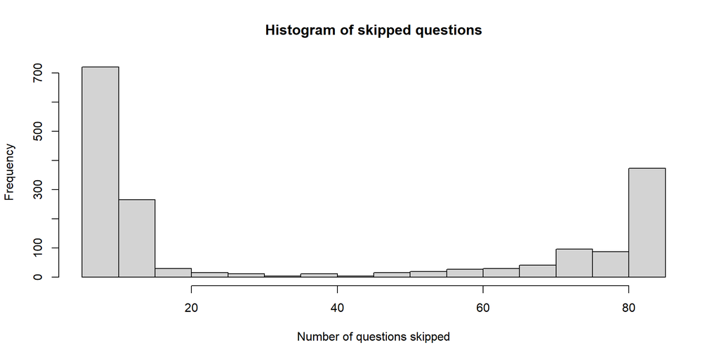

```r
rowSums(is.na(survey))|>hist(xlab="Number of questions skipped",
                             main = "Histogram of skipped questions"
                             )
```

### Missing data

```r
table_data<-survey|>
  count(Finished, ethnicity_race)|>
  ungroup()|>
  drop_na()|>
  group_by(ethnicity_race)|>
  mutate(
    proportion = n/sum(n)
  )|>
  ungroup()|>
  arrange(-n)|>
  pivot_wider(names_from=Finished, values_from = c(proportion, n))

table_data|>
  gt()|>
  fmt_percent(columns = starts_with("proportion"), decimals = 1)|>
  cols_merge_n_pct(col_n = n_True, col_pct= proportion_True)|>
  cols_merge_n_pct(col_n = n_False, col_pct= proportion_False)|>
  cols_label(ethnicity_race = "Race/Ethnicity",
             proportion_True = "% Complete",
             proportion_False  = "% Incomplete",
             n_True= "N Complete",
             n_False = "N Incomplete"
             )
```

### Missing data

| Race/Ethnicity | N Complete | N Incomplete |
| --- | --- | --- |
| White, non-Hispanic | 569 (79.2%) | 149 (20.8%) |
| Asian, non-Hispanic | 145 (69.7%) | 63 (30.3%) |
| Black, non-Hispanic | 100 (63.3%) | 58 (36.7%) |
| Hispanic/Latino | 97 (66.0%) | 50 (34.0%) |
| Multiple races, non-Hispanic | 75 (72.1%) | 29 (27.9%) |
| Other, non-Hispanic | 32 (82.1%) | 7 (17.9%) |

### Missing data

```r
# can be helpful to label the variables, if you haven't already:
#var_labels(survey$ethnicity_race) <-"Race/Ethnicity summary"

survey|>
  tbl_summary(include=ethnicity_race, by=Finished)|>
  modify_caption("**Incomplete responses by ethnicity/race**")
```

**Incomplete responses by ethnicity/race**

| **Characteristic** | **False** N = 731<sup>1</sup> | **True** N = 1,020<sup>1</sup> |
| --- | --- | --- |
| Race/Ethnicity summary |  |  |
| Asian, non-Hispanic | 63 (18%) | 145 (14%) |
| Black, non-Hispanic | 58 (16%) | 100 (9.8%) |
| Hispanic/Latino | 50 (14%) | 97 (9.5%) |
| Multiple races, non-Hispanic | 29 (8.1%) | 75 (7.4%) |
| Other, non-Hispanic | 7 (2.0%) | 32 (3.1%) |
| White, non-Hispanic | 149 (42%) | 569 (56%) |
| Unknown | 375 | 2 |

<sup>1</sup> n (%)

### Describing variables

- How many (valid) responses do you have?
- How are those responses distributed in the data?

## Correlations and alpha

### Correlation matrix

```r
levels<-c("Much less",
          "Moderately less",
          "Slightly less",
          "About the same",
          "Slightly more",
          "Moderately more")

spendgov_numeric<-survey|>
  select(starts_with("spendgov_"))|>
  apply(2, function(x) match(x, levels))


cmat<-spendgov_numeric|>
  cor(use = 'pairwise.complete.obs')

cmat
```

```
            spendgov_1  spendgov_2 spendgov_3  spendgov_4  spendgov_5
spendgov_1  1.00000000  0.56604634 -0.2125916  0.35816394 -0.02981643
spendgov_2  0.56604634  1.00000000 -0.1999595  0.40909316 -0.01750531
spendgov_3 -0.21259158 -0.19995955  1.0000000 -0.18710454  0.40924409
spendgov_4  0.35816394  0.40909316 -0.1871045  1.00000000  0.04712303
spendgov_5 -0.02981643 -0.01750531  0.4092441  0.04712303  1.00000000
spendgov_6  0.50821644  0.48587498 -0.2735960  0.35881755  0.04770339
spendgov_7 -0.11894495 -0.17392950  0.3254521 -0.08130880  0.25630679
spendgov_8  0.44526337  0.55883327 -0.3169506  0.39586566 -0.14198300
            spendgov_6 spendgov_7 spendgov_8
spendgov_1  0.50821644 -0.1189450  0.4452634
spendgov_2  0.48587498 -0.1739295  0.5588333
spendgov_3 -0.27359599  0.3254521 -0.3169506
spendgov_4  0.35881755 -0.0813088  0.3958657
spendgov_5  0.04770339  0.2563068 -0.1419830
spendgov_6  1.00000000 -0.1164100  0.4659649
spendgov_7 -0.11640996  1.0000000 -0.1398299
spendgov_8  0.46596492 -0.1398299  1.0000000
```

### Correlation plots

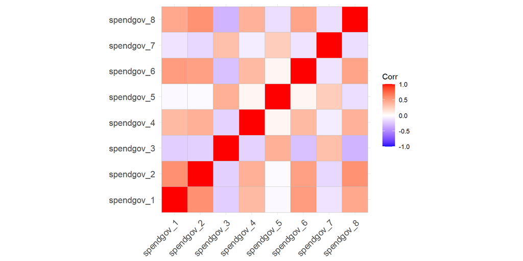

```r
library(ggcorrplot)

ggcorrplot(cmat)
```

### Correlation plots: recommendations

- We can change the `rownames` and `colnames` of the correlation matrix to a descriptive name (try to be concise, you probably can’t fit a full sentence here)

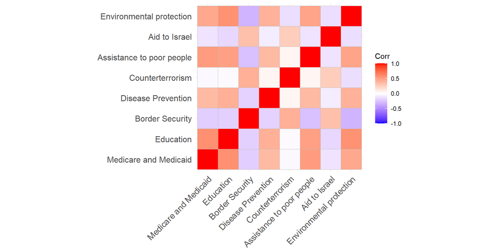

```r
names <- c(
  "Medicare and Medicaid",
  "Education",
  "Border Security",
  "Disease Prevention",
  "Counterterrorism",
  "Assistance to poor people",
  "Aid to Israel",
  "Environmental protection"
)
colnames(cmat) <- names
rownames(cmat) <-names

ggcorrplot(cmat)
```

### Correlation plots: recommendations

- You can also add the actual correlation values to the plot by setting `lab=TRUE`
- And add a title with `+ labs(title = "your title")`

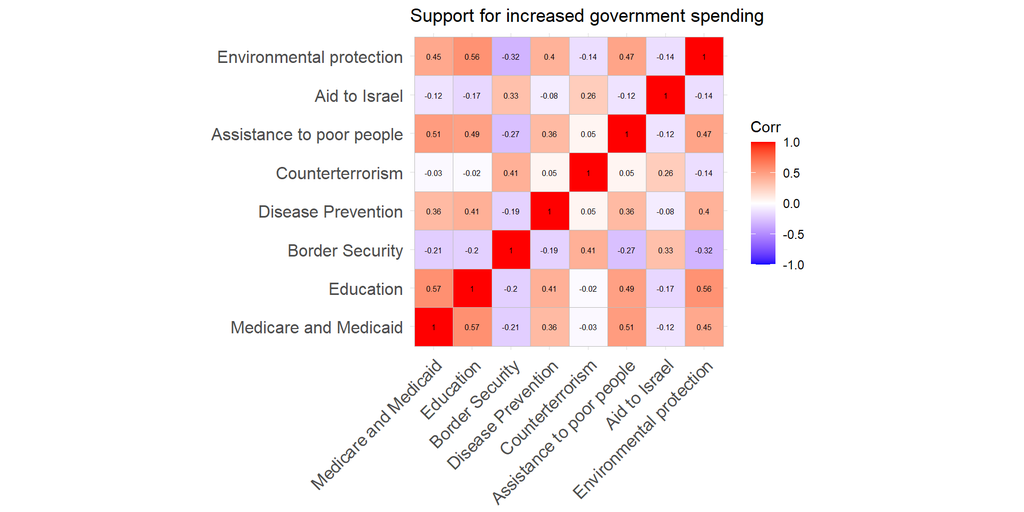

```r
names <- c(
  "Medicare and Medicaid",
  "Education",
  "Border Security",
  "Disease Prevention",
  "Counterterrorism",
  "Assistance to poor people",
  "Aid to Israel",
  "Environmental protection"
)

colnames(cmat) <- names
rownames(cmat) <-names

ggcorrplot(cmat,
           lab = TRUE,
           lab_size = 2
           ) +
  labs(title ="Support for increased government spending")
```

### Correlation plots: recommendations

- Get the correlation matrix for the numeric `trust_groups` measures you created in the previous section.
- Try adding `hc.order = TRUE` to the `ggcorrplot` command and note what changes.
- Try changing the color scheme.
- Try anything [from this](https://cran.r-project.org/web/packages/corrplot/vignettes/corrplot-intro.html)

### Correlation plots: recommendations

- Some characteristics seem to be negatively correlated here, which could be a red flag.
- This could point to a coding error, or it might suggest that there’s some other thing that these items are measuring.

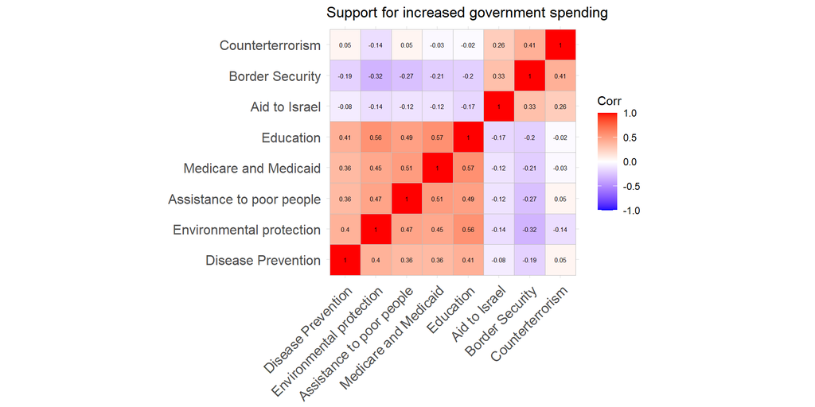

### Calculating alpha

We can use the `psych` package to calculate $\alpha$ from a correlation matrix:

```r
# install.packages("psych")
#?alpha
library(psych)
alphas<-psych::alpha(spendgov_numeric)
```

```
Some items ( spendgov_3 spendgov_5 spendgov_7 ) were negatively correlated with the first principal component and
probably should be reversed.
To do this, run the function again with the 'check.keys=TRUE' option
```

### Calculating alpha: components

```r
alphas$total
```

```
# A tibble: 1 × 9
  raw_alpha std.alpha `G6(smc)` average_r `S/N`    ase  mean    sd median_r
      <dbl>     <dbl>     <dbl>     <dbl> <dbl>  <dbl> <dbl> <dbl>    <dbl>
1     0.552     0.544     0.647     0.130  1.19 0.0167  3.75 0.996   0.0474
```

### Calculating alpha: components

The `alpha.drop` table shows the change in alpha values if we were to drop some items:

```r
alphas$alpha.drop
```

```
# A tibble: 8 × 8
  raw_alpha std.alpha `G6(smc)` average_r `S/N` `alpha se`  var.r   med.r
      <dbl>     <dbl>     <dbl>     <dbl> <dbl>      <dbl>  <dbl>   <dbl>
1     0.447     0.439     0.562    0.101  0.783     0.0211 0.0845  0.0471
2     0.433     0.424     0.541    0.0952 0.737     0.0215 0.0786  0.0471
3     0.637     0.628     0.677    0.194  1.69      0.0131 0.0753  0.256
4     0.491     0.466     0.598    0.111  0.872     0.0194 0.0993 -0.0175
5     0.550     0.544     0.635    0.146  1.19      0.0165 0.108   0.325
6     0.455     0.444     0.566    0.102  0.799     0.0208 0.0858 -0.0175
7     0.605     0.598     0.681    0.175  1.49      0.0147 0.0984  0.358
8     0.474     0.470     0.579    0.112  0.887     0.0200 0.0789  0.0471
```

### Calculating alpha: components

$\alpha$ is subject to sampling error like any other sample statistic. We can get a 95% confidence interval for the statistic using a variety of methods, but the Feldt method is quick and reported automatically along side the rest of the output here:

```r
alphas$feldt
```

```
   95% confidence boundaries (Feldt)
 lower alpha upper
  0.52  0.55  0.58
```

### Try it out

- Get the alpha value for the `trust_groups` measure and interpret your results.

### Suggestions

- You may not have your data yet, but you can write your analysis script now and then just re-run it as new data comes in. Be kind to your future self and include plenty of comments so you remember what your code is doing.
- If there’s a big issue with your results, you should talk about that in your initial analysis and think about ways you might address the problem.